# Modified HP Filter: Theory and Methodology

Muhammad Yaseen

School of Mathematical and Statistical Sciences, Clemson University  
myaseen208@gmail.com

Javed Iqbal

State Bank of Pakistan  
Javed.iqbal6@sbp.org.pk

M. Nadim Hanif

State Bank of Pakistan  
Nadeem.hanif@sbp.org.pk

2026-02-10

## 1 Introduction

This vignette provides a detailed explanation of the methodology underlying the Modified Hodrick-Prescott (HP) filter as implemented in the `mhpfilter` package. We cover the mathematical foundations, the cross-validation approach for optimal parameter selection, and empirical evidence supporting its use.

```r
library(mhpfilter)
library(fastverse)
library(tidyverse)
```

## 2 1. The Standard HP Filter

### 2.1 1.1 Problem Formulation

The Hodrick-Prescott (1997) filter decomposes a time series $y_t$ into a trend component $g_t$ and a cyclical component $c_t$:

$$y_t = g_t + c_t, \quad t = 1, 2, \ldots,
T$$

The filter estimates the trend by solving the optimization problem:

$$\min_{g_t} \left\{ \sum_{t=1}^{T}(y_t -
g_t)^2 + \lambda \sum_{t=3}^{T}[(g_t - g_{t-1}) - (g_{t-1} - g_{t-2})]^2
\right\}$$

This objective function balances two competing goals:

1. **Goodness of fit**: $\sum_{t=1}^{T}(y_t - g_t)^2$ - the trend should be close to the data
2. **Smoothness**: $\sum_{t=3}^{T}(\Delta^2 g_t)^2$ - the trend’s growth rate should not change too rapidly

The smoothing parameter $\lambda$ controls the trade-off:

- $\lambda \to 0$: Trend equals original series (no smoothing)
- $\lambda \to \infty$: Trend is a linear time trend (maximum smoothing)

### 2.2 1.2 Matrix Formulation

The solution can be expressed in matrix form. Define the second-difference operator matrix $K$ of dimension $(T-2) \times T$:

$$K = \begin{pmatrix}
1 & -2 & 1 & 0 & \cdots & 0 \\
0 & 1 & -2 & 1 & \cdots & 0 \\
\vdots & & \ddots & \ddots & \ddots & \vdots \\
0 & \cdots & 0 & 1 & -2 & 1
\end{pmatrix}$$

Let $A = K'K$. Then the HP filter solution is:

$$\hat{g} = (I + \lambda A)^{-1}
y$$

where $I$ is the $T \times T$ identity matrix.

### 2.3 1.3 The Problem with Fixed Lambda

Hodrick and Prescott (1997) recommended $\lambda = 1600$ for quarterly U.S. GDP data, based on the assumption that:

> “A 5 percent cyclical component is moderately large, as is one-eighth of 1 percent change in the growth rate in a quarter.”

This led to $\lambda = (5 / 0.125)^2 = 1600$.

However, this assumption may not hold for:

- Different countries (emerging markets have more volatile cycles)
- Different series (investment is more volatile than consumption)
- Different time periods (Great Moderation vs earlier periods)

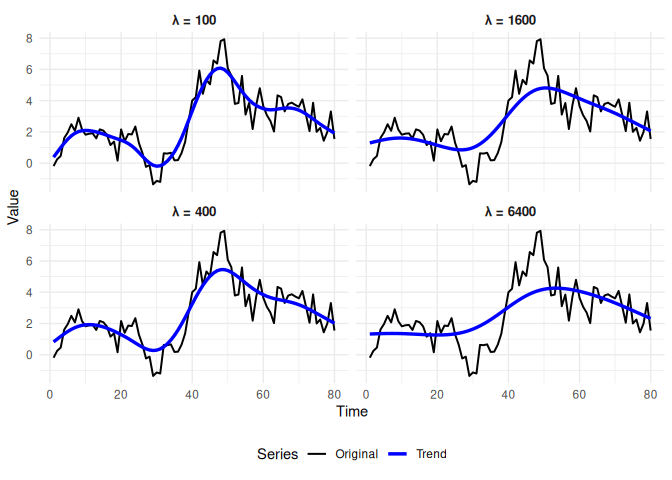

Effect of Lambda on Trend Smoothness

```r
set.seed(100)
y <- cumsum(rnorm(80)) + 2*sin((1:80)*pi/20)

lambdas <- c(100, 400, 1600, 6400)

# Create data frame for all lambda values
plot_data <- data.frame()

for (lam in lambdas) {
  result <- hp_filter(y, lambda = lam)

  temp_data <- data.frame(
    time = rep(1:length(y), 2),
    value = c(y, result$trend),
    series = rep(c("Original", "Trend"), each = length(y)),
    lambda = paste("λ =", lam)
  )

  plot_data <- rbind(plot_data, temp_data)
}

# Create faceted plot with combined legend
ggplot(plot_data, aes(x = time, y = value, color = series, linewidth = series)) +
  geom_line() +
  scale_color_manual(values = c("Original" = "black", "Trend" = "blue")) +
  scale_linewidth_manual(values = c("Original" = 0.7, "Trend" = 1.2)) +
  facet_wrap(~ lambda, ncol = 2) +
  labs(x = "Time", y = "Value", color = "Series", linewidth = "Series") +
  theme_minimal() +
  theme(legend.position = "bottom",
        strip.text = element_text(size = 10, face = "bold"))
```

## 3 2. The Modified HP Filter

### 3.1 2.1 Cross-Validation Approach

The Modified HP filter, developed by McDermott (1997) and applied empirically by Choudhary, Hanif & Iqbal (2014), selects $\lambda$ using **generalized cross-validation (GCV)**.

The idea is based on leave-one-out cross-validation:

1. For each observation $k$, fit the HP filter to all data *except* $y_k$
2. Predict the left-out observation using the fitted trend
3. Choose $\lambda$ that minimizes the average prediction error

Let $g_{T,\lambda}^{(k)}(t_k)$ denote the predicted value at time $k$ from the spline fitted leaving out observation $k$. The cross-validation function is:

$$CV(\lambda) = \frac{1}{T} \sum_{k=1}^{T}
\left(y_k - g_{T,\lambda}^{(k)}(t_k)\right)^2$$

### 3.2 2.2 Generalized Cross-Validation

Computing the leave-one-out CV is computationally intensive. Craven & Wahba (1979) showed it can be approximated by the **generalized cross-validation** (GCV) function:

$$GCV(\lambda) = \frac{T^{-1}
\sum_{k=1}^{T}(y_k - g_{t,k}^\lambda)^2}{\left(1 -
\frac{1}{T}\text{tr}(B(\lambda))\right)^2}$$

where $B(\lambda) = (I + \lambda A)^{-1}$ is the “hat matrix” and $g_{t,k}^\lambda = \sum_{s=1}^{T} b_{ks}(\lambda) y_s$.

Using Silverman’s (1984) approximation for the trace:

$$\text{tr}(B(\lambda)) \approx
\frac{T}{\lambda}$$

This yields the simplified GCV formula used in this package:

$$GCV(\lambda) = T^{-1} \left(1 +
\frac{2T}{\lambda}\right) \sum_{k=1}^{T}(y_k -
g_{t,k}^\lambda)^2$$

### 3.3 2.3 Algorithm

The algorithm implemented in `mhpfilter` is:

1. Compute $A = K'K$ once (shared across all $\lambda$ values)
2. For $\lambda = 1, 2, \ldots, \lambda_{max}$:
   - Compute trend: $g = (I + \lambda A)^{-1} y$
   - Compute residuals: $r = y - g$
   - Compute GCV: $GCV(\lambda) = T^{-1}(1 + 2T/\lambda) \cdot r'r$
3. Select $\lambda^* = \arg\min_\lambda GCV(\lambda)$
4. Return final decomposition using $\lambda^*$

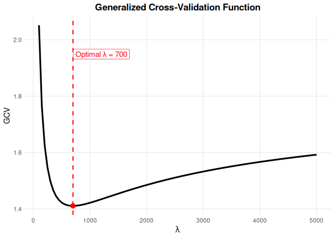

GCV as a Function of Lambda

```r
set.seed(42)
y <- cumsum(rnorm(100, 0.5, 0.3)) + arima.sim(list(ar = 0.8), 100)

# Compute GCV for range of lambdas
lambdas <- seq(100, 5000, by = 50)
gcv_values <- sapply(lambdas, function(lam) {
  res <- hp_filter(y, lambda = lam, as_dt = FALSE)
  T <- length(y)
  resid_ss <- sum((y - res$trend)^2)
  (1 + 2*T/lam) * resid_ss / T
})

# Create data frame for plotting
plot_data <- data.frame(
  lambda = lambdas,
  gcv = gcv_values
)

# Find minimum
opt_idx <- which.min(gcv_values)
opt_lambda <- lambdas[opt_idx]
opt_gcv <- gcv_values[opt_idx]

# Create ggplot
ggplot(plot_data, aes(x = lambda, y = gcv)) +
  geom_line(linewidth = 1.2) +
  geom_vline(xintercept = opt_lambda, color = "red", linetype = "dashed", linewidth = 0.8) +
  geom_point(data = data.frame(lambda = opt_lambda, gcv = opt_gcv),
             aes(x = lambda, y = gcv),
             color = "red", size = 3) +
  # Corrected: Use annotate() instead of geom_label() with aes()
  annotate("label",
           x = opt_lambda + 500,
           y = max(gcv_values) * 0.95,
           label = paste("Optimal λ =", opt_lambda),
           color = "red",
           fill = "white",
           size = 4) +
  labs(
    x = expression(lambda),
    y = "GCV",
    title = "Generalized Cross-Validation Function"
  ) +
  theme_minimal() +
  theme(
    plot.title = element_text(hjust = 0.5, size = 14, face = "bold"),
    axis.title = element_text(size = 12),
    panel.grid.minor = element_blank()
  )
```

## 4 3. Why Modified HP Filter Works Better

### 4.1 3.1 Simulation Evidence

Choudhary et al. (2014) conducted Monte Carlo simulations comparing the standard HP filter with the Modified HP filter. The data generating process was:

$$g_t = \mu + g_{t-1} + \varepsilon_t,
\quad \varepsilon_t \sim N(0, \sigma_\varepsilon^2)$$
$$c_t = \phi_1 c_{t-1} + \phi_2 c_{t-2} + \xi_t,
\quad \xi_t \sim N(0, \sigma_\xi^2)$$

They varied:

- The ratio $\sigma_\varepsilon / \sigma_\xi$ (relative importance of trend vs cycle)
- AR coefficients $\phi_1, \phi_2$ (cycle persistence)
- Linear vs nonlinear trend specifications

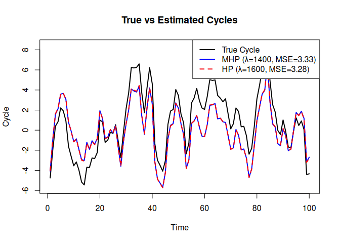

Simulation: True vs Estimated Cycles

```r
set.seed(2024)
n <- 100

# Generate true components
trend_true <- cumsum(c(0, rnorm(n-1, 0.5, 0.2)))
cycle_true <- arima.sim(list(ar = c(1.2, -0.4)), n, sd = 1.5)
y <- trend_true + cycle_true

# Apply both filters
mhp_result <- mhp_filter(y, max_lambda = 10000)
hp_result <- hp_filter(y, lambda = 1600)

# Compute MSE
mse_mhp <- mean((mhp_result$cycle - cycle_true)^2)
mse_hp <- mean((hp_result$cycle - cycle_true)^2)

oldpar <- par(mfrow = c(1, 1))
plot(cycle_true, type = "l", lwd = 2, ylim = range(c(cycle_true, mhp_result$cycle, hp_result$cycle)),
     main = "True vs Estimated Cycles", ylab = "Cycle")
lines(mhp_result$cycle, col = "blue", lwd = 2)
lines(hp_result$cycle, col = "red", lwd = 2, lty = 2)
legend("topright",
       c(paste0("True Cycle"),
         paste0("MHP (λ=", get_lambda(mhp_result), ", MSE=", round(mse_mhp, 2), ")"),
         paste0("HP (λ=1600, MSE=", round(mse_hp, 2), ")")),
       col = c("black", "blue", "red"), lty = c(1, 1, 2), lwd = 2)
```

```r
par(oldpar)
```

### 4.2 3.2 Empirical Evidence

Choudhary et al. (2014) estimated optimal $\lambda$ for 93 countries using annual data and 25 countries using quarterly data. Key findings:

| Statistic | Annual Data | Quarterly Data |
| --- | --- | --- |
| Range of λ | 11 - 6,566 | 229 - 4,898 |
| Fixed λ | 100 | 1,600 |

```r
# Demonstrate cross-country variation
set.seed(999)

# Simulate countries with different characteristics
countries <- data.table(
  name = c("Stable_Developed", "Volatile_Emerging", "Moderate"),
  trend_sd = c(0.2, 0.5, 0.3),
  cycle_sd = c(0.5, 2.0, 1.0),
  cycle_ar = c(0.9, 0.7, 0.8)
)

results <- lapply(1:nrow(countries), function(i) {
  trend <- cumsum(rnorm(80, 0.5, countries$trend_sd[i]))
  cycle <- arima.sim(list(ar = countries$cycle_ar[i]), 80, sd = countries$cycle_sd[i])
  y <- trend + cycle
  res <- mhp_filter(y, max_lambda = 10000)
  data.table(country = countries$name[i], lambda = get_lambda(res))
})

print(rbindlist(results))
```

```
#>              country lambda
#>               <char>  <int>
#> 1:  Stable_Developed    714
#> 2: Volatile_Emerging    604
#> 3:          Moderate    401
```

## 5 4. Theoretical Justification

### 5.1 4.1 Why Cross-Validation?

Cross-validation is optimal in the sense that it asymptotically minimizes the **integrated squared error** between the estimated trend and the true trend (Craven & Wahba, 1979).

The GCV function has several desirable properties:

1. **Rotation invariant**: Does not depend on the coordinate system
2. **Asymptotically optimal**: Converges to the best possible $\lambda$
3. **Computationally efficient**: Closed-form approximation available

### 5.2 4.2 Relationship to Signal Extraction

The HP filter can be viewed as a Wiener-Kolmogorov filter for signal extraction. If:

- Trend follows a random walk: $\Delta^2 g_t = \varepsilon_t$
- Cycle is stationary noise: $c_t$ stationary

Then $\lambda = \sigma_c^2 / \sigma_\varepsilon^2$ is the optimal filter.

The GCV approach implicitly estimates this ratio from the data.

### 5.3 4.3 Connection to Spline Smoothing

The HP filter is equivalent to a cubic smoothing spline. The GCV method for choosing $\lambda$ is the same used in spline smoothing literature (Silverman, 1984).

## 6 5. Practical Recommendations

### 6.1 5.1 When to Use Modified HP Filter

**Use Modified HP when**:

- Analyzing series from different countries (cross-country comparisons)
- Working with different macro variables (GDP, consumption, investment)
- Unsure about appropriate λ for your specific context
- Need defensible, data-driven parameter selection

**Standard HP may be acceptable when**:

- Following established literature conventions exactly
- Comparing results with published studies using λ = 1600
- Time series closely matches U.S. quarterly GDP characteristics

### 6.2 5.2 Choosing max_lambda

The `max_lambda` parameter affects computation time and search range:

| max_lambda | Use Case | Speed |
| --- | --- | --- |
| 5,000 | Quick exploratory analysis | ~0.05s |
| 10,000 | Most quarterly macro series | ~0.1s |
| 50,000 | Conservative, unusual series | ~0.5s |
| 100,000 | Very smooth trends needed | ~1s |

```r
# For most macro applications, 10000 is sufficient
result <- mhp_filter(y, max_lambda = 10000)
cat("Optimal lambda:", get_lambda(result), "\n")
```

```
#> Optimal lambda: 1400
```

```r
# If optimal λ hits the upper bound, increase max_lambda
if (get_lambda(result) >= 9900) {
  warning("Lambda near upper bound - consider increasing max_lambda")
}
```

### 6.3 5.3 Interpreting Results

Key diagnostics when comparing HP vs Modified HP:

```r
comp <- mhp_compare(y, frequency = "quarterly")
print(comp)
```

```
#>         method lambda cycle_sd   cycle_mean       ar1 cycle_range      gcv
#>         <char>  <num>    <num>        <num>     <num>       <num>    <num>
#> 1:          HP   1600 2.444616 1.890115e-12 0.7519842    12.29935       NA
#> 2: Modified HP   1400 2.424745 1.567173e-12 0.7477953    12.20010 6.652109
```

```r
# Interpretation guide:
# 1. Large lambda difference: series-specific smoothing important
# 2. Positive sd_diff: HP under-estimates cycle volatility
# 3. Large ar1_diff: affects model calibration
```

## 7 6. Mathematical Appendix

### 7.1 6.1 Derivation of HP Filter Solution

The first-order conditions of the minimization problem:

$$\frac{\partial}{\partial g} \left[
(y-g)'(y-g) + \lambda g'A g \right] = 0$$

$$-2(y-g) + 2\lambda A g = 0$$

$$(I + \lambda A)g = y$$

$$g = (I + \lambda A)^{-1} y$$

### 7.2 6.2 Structure of Matrix A

The matrix $A = K'K$ is a symmetric, positive semi-definite band matrix:

$$A = \begin{pmatrix}
1 & -2 & 1 & 0 & 0 & \cdots \\
-2 & 5 & -4 & 1 & 0 & \cdots \\
1 & -4 & 6 & -4 & 1 & \cdots \\
0 & 1 & -4 & 6 & -4 & \cdots \\
\vdots & & & \ddots & & \\
\end{pmatrix}$$

This banded structure allows efficient computation using sparse matrix methods (not exploited in this implementation, but potential for future optimization).

### 7.3 6.3 GCV Approximation

Starting from:

$$GCV(\lambda) = \frac{T^{-1} \|y -
\hat{g}\|^2}{(1 - T^{-1}\text{tr}(B))^2}$$

Using $(1-x)^{-2} \approx 1 + 2x$ for small $x$:

$$GCV(\lambda) \approx T^{-1} \|y -
\hat{g}\|^2 (1 + 2T^{-1}\text{tr}(B))$$

With Silverman’s approximation $\text{tr}(B) \approx T/\lambda$:

$$GCV(\lambda) \approx T^{-1}(1 +
2T/\lambda) \|y - \hat{g}\|^2$$

## 8 References

1. Choudhary, M.A., Hanif, M.N., & Iqbal, J. (2014). On smoothing macroeconomic time series using the modified HP filter. *Applied Economics*, 46(19), 2205-2214.
2. Craven, P., & Wahba, G. (1979). Smoothing noisy data with spline functions. *Numerische Mathematik*, 31, 377-403.
3. Hodrick, R.J., & Prescott, E.C. (1997). Postwar US business cycles: An empirical investigation. *Journal of Money, Credit and Banking*, 29(1), 1-16.
4. Marcet, A., & Ravn, M.O. (2004). The HP-filter in cross-country comparisons. *CEPR Discussion Paper* No. 4244.
5. McDermott, C.J. (1997). An automatic method for choosing the smoothing parameter in the HP filter. Unpublished manuscript, IMF.
6. Ravn, M.O., & Uhlig, H. (2002). On adjusting the Hodrick-Prescott filter for the frequency of observations. *Review of Economics and Statistics*, 84(2), 371-376.
7. Silverman, B.W. (1984). A fast and efficient cross-validation method for smoothing parameter choice in spline regression. *Journal of the American Statistical Association*, 79, 584-589.